# Dietary Variation in the Northern Goshawk (Accipiter gentilis) in British Columbia

# Introduction

Effective wildlife conservation often requires understanding diet composition and its consequences for population demographics. Specialist predators selectively consume a narrow range of prey species regardless of their abundance, whereas generalists opportunistically consume a wider range and readily switch between species in response to changes in prey abundance (Steenhof and Kochert 1988; Terraube and Arroyo 2011). Specialization increases foraging efficiency on the preferred prey at the potential cost of decreased reproductive success for the specialist when that prey is scarce (Newton 1998). However, even in a generalist predator a single key prey species can be a major driver of reproductive success (Elmhagen et al. 2000; Resano‐Mayor et al. 2016). For at-risk predators, increasing the abundance of key prey species may be a useful conservation tool (Ferrer and Negro 2004; Forsman et al. 2004; Resano‐Mayor et al. 2016).

The northern goshawk (*Accipiter gentilis*) is a large forest-dwelling raptor with a Holarctic distribution. A generalist predator, the goshawk hunts a variety of small- and medium-sized mammals and birds, including squirrels, rabbits and hares, grouse, jays and crows, and pigeons (Squires et al. 2020). Despite this diverse diet, a single prey species or narrow suite of species has a strong effect on the demographics of many goshawk populations. In the Yukon, goshawks depend on snowshoe hare (*Lepus americanus*) and show strong variation in productivity, mortality, and space use in response to cyclical changes in hare abundance (Doyle and Smith 1994). Goshawks in Scandinavia likewise rely on a single prey taxa and show changes in productivity and occupancy based on the annual abundance of four grouse species (subfamily Tetraoninae) (Tornberg et al. 2005). In contrast, goshawks in the American Southwest have a wide prey base and regularly take some fourteen different species (Boal and Mannan 1994). Fluctuations in goshawk productivity in this region are small and driven by total prey abundance, though the most influential single species is red squirrel (*Tamiasciurus hudsonicus*) (Salafsky et al. 2007). These examples suggest the identity and influence of key prey species in such an adaptable predator is specific to each region.

In British Columbia, Canada, the coastal population of northern goshawks is the subject of federal and provincial management which focuses on the protection of breeding habitat to increase nest site availability (COSEWIC 2013). Like many raptors, goshawk populations are generally considered to be limited by nest site availability as well as prey abundance (Reynolds, Wiens, and Salafsky 2006; Rutz et al. 2006). However, current management plans do not include protections for foraging habitat or actions to increase prey populations, in part due to a lack of knowledge regarding goshawk diet and foraging behavior in coastal BC. Goshawk diet in this region is variable, with hawks on Vancouver Island, British Columbia, consuming primarily red squirrels (Ethier 1999), whereas hawks in nearby southeast Alaska (Lewis, Titus, and Fuller 2006) and western Washington (Bloxton 2002) take mostly medium and large birds. Even within British Columbia, a gradient of forest types from wet coastal to dry interior may produce dietary variation at smaller scales (NGRT 2008). Detailed, local information on goshawk diet and its effect on reproductive success is necessary to include limiting factors beyond nest site availability into management plans.

Here we describe the breeding season diet of northern goshawks in coastal British Columbia over a two-year period. We assess whether goshawk diet differs within this region between the wetter *coastal* zone and the drier *transition* zone. We further evaluate whether dietary variables (composition, diversity) influence goshawk reproductive success.

# Methods

### Study Area and Species

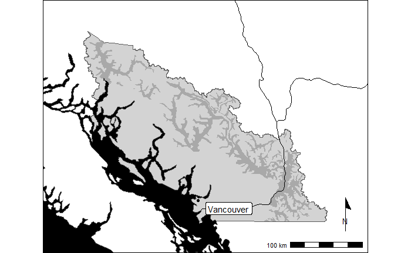

In North America, the northern goshawk ranges from boreal forests of the Yukon south to high-elevation forests of Arizona and New Mexico. Two subspecies are recognized: the widespread *atricapillus* and the limited *laingi* (Squires et al. 2020). The *laingi* subspecies was first described on the Haida Gwaii archipelago in British Columbia and is smaller and darker than the *atricapillus* subspecies found elsewhere on the continent (Taverner 1940). The range of this subspecies is limited to the west coast of North America from southeast Alaska through mainland British Columbia and Vancouver Island, possibly as far south as Washington’s Olympic Peninsula (COSEWIC 2013). *A. g. laingi* is considered a species at risk in British Columbia by both the federal and provincial governments due to significant habitat loss from industrial timber harvest (NGRT 2008; COSEWIC 2013).

We studied goshawks in southwestern British Columbia, a region characterized by rugged mountains interspersed with coastal fjords and low-lying valleys. The maritime climate supports temperate rainforest dominated by Douglas-fir (*Pseudotsuga menziesii*), western redcedar (*Thuja plicata*), and western hemlock (*Tsuga heterophylla*) (Meidinger and Pojar 1991). The goshawk population in southwestern BC is currently classified as *A. g. laingi*, though new genetic evidence may lead to future reclassification (Geraldes et al. 2018). Within this region, goshawk managers have delineated a *transition zone* comprised of low-elevation valleys connecting the wet forests of the *coast zone* with the dry interior forests east of the Coast Mountains. This narrow transition zone contains forest types intermediate between the western and eastern forests and likely represents an area of overlap between the coastal *laingi* population and the interior *atricapillus* population (NGRT 2008).

### Data Collection

We assessed goshawk diet during the 2019 and 2020 breeding seasons through a combination of egested pellets, prey remains, and nest camera photos collected from 25 nests across the coastal (*n* = 11) and transition (*n* = 14) zones. Goshawk nests were located as part of long-term monitoring conducted by the British Columbia Ministry of Forests, Lands, Natural Resource Operations and Rural Development (FLNRO) (for detailed survey methodology see McClaren (2005)).

Prey remains and egested pellets were collected from 24 sites (2019 *n* = 18, 2020 *n* = 15) with active nests. There were 9 sites included in both years. Pellets and remains were gathered from beneath active nests, from within nests after juveniles had fledged, and from plucking posts located within the site. All prey remains and all pellets from a single collection location (i.e., one nest or one plucking post) were combined into a single sample for each visit to that location.

At a subset of these sites (2019 *n* = 6, 2020 *n* = 7), cameras were installed at nests to record prey delivered to chicks. There were 2 nests included in both years. Nest cameras are an effective and relatively unbiased method of measuring avian diet (García-Salgado et al. 2015 ; Harrison et al. 2019). However, cameras may overestimate prey deliveries because goshawks cache prey items for redelivery to the nest at a later time, creating a risk of double-counting items. Due to the discrete nature of our data, we were unable to differentiate cached, re-delivered items from new items and did not attempt to account for caching in our analysis.

Nest cameras were digital trail cameras (Reconyx brand, UltraFire and HyperFire models) mounted 2-5 meters distant from and slightly above the nest, usually in an adjacent tree. Cameras in 2019 were programmed to take three photos one second apart when triggered by motion, and an additional one photo every thirty minutes. In 2020, cameras were programmed to take five photos one second apart when triggered by motion, and an additional one photo every twenty minutes. Installation took place during the early nestling phase (between 4 June and 18 July) and cameras were left in place until after juveniles dispersed in the fall. Camera site selection was not random but constrained by topography, access, and timing of discovery.

Breeding chronology was not available for most sites. At 12 of the sites with cameras (2019 *n* = 6, 2020 *n* = 6), chicks were aged from photos taken shortly after camera installation using a pictorial guide (Boal 1994). Productivity was defined as the number of chicks to reach 32 days age (Boal 1994; McClaren, Kennedy, and Dewey 2002).

### Diet Quantification

We reconstructed prey from pellets and prey remains following a modification of the protocol used by Lewis, Fuller, and Titus (2004). Within each sample, prey remains were identified to the lowest possible taxonomic category and the minimum number of individuals counted (i.e. 3 hare femurs = 2 *Lepus americanus*). Intact pellets and broken but reassembled pellets were analyzed individually within each sample, while fragmented pellets were combined within each sample. Pellets were dissected and feathers, fur, and hard parts (bones, teeth, claws) were identified to the lowest taxonomic level. We counted the minimum number of individuals represented within the pellet or pellet collection. Prey items were additionally categorized by size (small = sparrow- or vole-sized, medium = jay- or squirrel-sized, and large = grouse- or hare-sized).

Prey items identified to species were assigned mass using data from the literature. We assigned mass to mammal species from Nagorsen (2002) and to birds from Billerman et al. (2020), using the geographically closest estimates and averaging the mass of males and females. When unable to differentiate between species within a single, relatively homogeneous genus (such as *Eutamias* or *Myotis*), we assigned mass by averaging the masses of all possible species, based on range maps. Red squirrels (*Tamiasciurus hudsonicus*) were present at a single site within out study area; when unable to distinguish between the two members of the genus *Tamiasciurus* we assigned the item to the more common *T. douglasii*. Unidentified items were assigned mass by averaging the masses of the identified species in that size category and taxonomic class. As very few items could be successfully aged, we did not include prey age in our analysis.

Data from prey remains and egested pellets are known to be biased indices of diet. Some authors have found combining data from both sources to produce relatively unbiased results that can serve as a helpful supplement to camera data (Lewis, Fuller, and Titus 2004) (Simmons et al 1991). However, after testing for differences between pooled pellets-and-remains and camera data we found significant differences between these two sources. We therefore report results from pellets and pooled pellets-and-remains separately. We do not report results from prey remains alone, as diet composition estimates from prey remains are highly biased and infrequently used in raptor diet studies.

Nest camera photos were reviewed and each new prey item delivered to the nest was recorded and identified to species when possible. When items could not be identified to species, they were identified to the lowest possible taxonomic level. Prey items identified from photos were assigned a size category and biomass by the same method used for remains and pellets. Partial items were assigned the average mass for that size category and taxonomic class.

### Statistical Analysis

Sites were classified as either coastal or transition based on whether the site centroid fell within the transition zone defined by NGRT (2008). We determined the site centroid by locating the central point between all known nests within each site. Using data from pellets, pooled pellets-and-remains, and nest cameras, we quantified the diet of each zone in the same manner as for the overall study area.

We pooled all data within each source (cameras, pellets, pooled pellets and remains) and within each zone (coastal, transition) and tested for differences between the zones with a chi-squared test using counts of items.

To determine the potential reproductive consequences of dietary variation, we examined how two aspects of diet, diet diversity and proportion of biomass composed of squirrel, influenced productivity. We used linear regressions in R (R Core Team 2020) with productivity as the response variable and diet as the explanatory variable. Because productivity data were available only from sites with nest cameras and nest-level diet data from pellets and prey remains were sparse, we performed this analysis using only diet data from nest cameras.

# Results

## Goshawk Diet

We identified a total of 135 prey items from pellets collected at 20 sites. Of these, 58% could be identified to genus or better, and no item could not be identified at least to class. From pellets alone, only 9 unique prey species or homogenous genera (i.e. *Neotamias*) were identified. Another 121 items were identified from prey remains collected at 22 sites, of which 51% were identified to genus or better and none could not be identified to class. From the combined pellets-and-remains sample a total of 21 unique prey species or homogenous genera were identified.

The majority of the prey items identified from pellets were mammals (75% biomass, 59% count). Squirrels made up 61% of biomass (41% of counts), while other birds (neither grouse, corvids, nor thrushes) made up another 21% (36% by count) and other mammals (neither tree squirrels nor hares) made up 15% of biomass (18% of counts). The remaining 4% of biomass (5% of counts) was made up of corvids and thrushes.

The combined pellets-and-remains sample showed a very different composition, with only 37% of the diet made up of mammals and the majority made up of birds. The most commonly identified prey group was grouse (37% biomass, 16% counts), followed by other birds (23% biomass, 35% counts). Squirrels made up only 14% (24% counts) of the combined sample

We recorded a total of 518 prey item deliveries on nest cameras, though camera effectiveness varied between sites: an average of 35 items were recorded per site, but one site had only one item recorded while another recorded 69 items. This variability was due to differences in camera placement and sensitivity settings. Some deliveries were obscured from the camera during delivery and consumption and were entirely removed from the analysis. Of the remaining 450 visible items we were able to identify 78% to class and 60% to genus or better. Small and medium birds were disproportionately represented among items only identified to class, frequently arriving at the nest already plucked and decapitated.

## Difference between ecological regions

A chi-squared test of pellet data alone did not show a significant difference between goshawk diet in the coastal and transition zones (X = 7.53, *p* = 0.1). However, a chi-squared test of the pooled pellet-and-remains data did show a significant difference (X = 41.75, *p* = 0), as did a test of the camera data (X = 23.84, *p* = 0).

## Productivity

We found no affect on goshawk productivity of either the proportion of diet composed of squirrel biomass (*p* = 0.44) or diet diversity (*p* = 0.28). There was also no significant difference in goshawk productivity between the coastal and transitional zones (*p* = 0.4).

# Discussion

Several sources of bias complicate our conclusions, the greatest of which stems from the source of diet data. We used three sources of data to quantify goshawk diet–egested pellets, prey remains, and nest cameras–and found significant differences between the results they produced. Cameras are widely considered one of the least biased methods for measuring diet at the nest in raptors (Tornberg and Reif 2007; García-Salgado et al. 2015; Harrison et al. 2019). We therefore consider our results from the nest cameras to be the truest approximation of goshawk diet, although we acknowledge that cameras are not entirely free of bias. Compared to cameras, prey remains were the most biased, grossly overestimating the proportion of the diet composed of avian prey. For this reasons we did not analyze prey remains alone, but the avian bias carried into the pooled pellets-and-remains sample, which we did analyze. On the other hand, pellets allowed few prey items to be identified to species, while prey remains allowed the identification of a large number of species, including several–primarily birds–not captured by cameras. These complex and contradictory results highlight the importance of clearly reporting the source of raptor diet data. Because each of these sources has been used in past diet studies, we believe there is value in reporting the results of each for ease of comparison. However, we recommend future diet studies prioritize collecting data via cameras, either video or still images, rather than physical specimens.

Our study answers several fundamental questions regarding the basic ecology of an at-risk population of northern goshawks, but many more remain unanswered. We were unable to collect data on prey abundance and so cannot draw any conclusions regarding goshawk prey selection. Furthermore, while nest cameras are an effective way to measure prey delivered to the nest, they cannot record prey consumed by adults away from the nest, prey consumed by juveniles after they have fledged, or prey consumed during the winter. As a result, we captured an incomplete picture of breeding season diet and have no insight into nonbreeding season diet. These limitations are not exclusive to our work: few studies have successfully combined prey abundance with both goshawk diet and reproductive success, and no North American study has comprehensively addressed goshawk diet away from the nest (Rutz et al. 2006; Squires and Kennedy 2006). Filling these gaps represents an important direction for future studies of northern goshawks in British Columbia and throughout the species’ range.

# Literature Cited

Billerman, S. M., B. K. Keeney, P. G. Rodewald, and T. S. Schulenberg, eds. 2020. *Birds of the World*. Ithaca, NY, USA: Cornell Lab of Ornithology. https://birdsoftheworld-org.proxy.lib.sfu.ca/bow/home.

Bloxton, Thomas David, Jr. 2002. “Prey Abundance, Space Use, Demography, and Foraging Habitat of Northern Goshawks in Western Washington.” Master of Science, University of Washington.

Boal, Clint W. 1994. “A Photographic and Behavioral Guide to Aging Nestling Northern Goshawks.” *Studies in Avian Biology* 16: 32–40.

Boal, Clint W, and R William Mannan. 1994. “NORTHERN GOSHAWK DIETS IN PONDEROSA PINE FORESTS ON THE KAIBAB PLATEAU,” no. 16: 6.

Carey, Andrew B. 1995. “Sciurids in Pacific Northwest Managed and Old-Growth Forests.” *Ecological Applications* 5 (3): 648–61. https://doi.org/10.2307/1941974.

Carey, Andrew B., Scott P. Horton, and Brian L. Biswell. 1992. “Northern Spotted Owls: Influence of Prey Base and Landscape Character.” *Ecological Monographs* 62 (2): 223–50. https://doi.org/10.2307/2937094.

COSEWIC. 2013. “COSEWIC Assessment and Status Report on the Northern Goshawk Accipiter Gentilis Laingi in Canada.” Ottawa, ON: Committee on the Status of Endangered Wildlife in Canada. [http://www.sararegistry.gc.ca/virtual_sara/files/cosewic/sr_autour _palombes_northern_goshawk_1213_e.pdf](http://www.sararegistry.gc.ca/virtual_sara/files/cosewic/sr_autour%20_palombes_northern_goshawk_1213_e.pdf).

DeStefano, S., M. T. McGrath, S. K. Daw, and S. M. Desimone. 2006. “Ecology and Habitat of Breeding Northern Goshawks in the Inland Pacific Northwest: A Summary of Research in the 1990s.” *Studies in Avian Biology*, no. 31: 75–84. http://pubs.er.usgs.gov/publication/70028410.

Doyle, Frank I., and James M. N. Smith. 1994. “Population Responses of Northern Goshawks to the 10-Year Cycle in Numbers of Snowshoe Hares.” *Studies in Avian Biology* 16: 122–29.

Elmhagen, Bodil, Magnus Tannerfeldt, Paolo Verucci, and Anders Angerbjörn. 2000. “The Arctic Fox (Alopex Lagopus): An Opportunistic Specialist.” *Journal of Zoology* 251 (2): 139–49. https://doi.org/https://doi.org/10.1111/j.1469-7998.2000.tb00599.x.

Ethier, Thomas J. 1999. “Breeding Ecology and Habitat of Northern Goshawks (Accipiter Gentilis Laingi) on Vancouver Island: A Hierarchical Approach.” PhD thesis, Victoria, BC: University of Victoria.

Ferrer, Miguel, and Juan José Negro. 2004. “The Near Extinction of Two Large European Predators: Super Specialists Pay a Price.” *Conservation Biology* 18 (2): 344–49. https://doi.org/https://doi.org/10.1111/j.1523-1739.2004.00096.x.

Forsman, Eric D., Robert G. Anthony, E. Charles Meslow, and Cynthia J. Zabel. 2004. “Diets and Foraging Behavior of Northern Spotted Owls in Oregon.” *Journal of Raptor Research* 38 (3 (September)): 214–30.

García-Salgado, Gonzalo, Salvador Rebollo, Lorenzo Pérez-Camacho, Sara Martínez-Hesterkamp, Alberto Navarro, and José-Manuel Fernández-Pereira. 2015. “Evaluation of Trail-Cameras for Analyzing the Diet of Nesting Raptors Using the Northern Goshawk as a Model.” *PLoS ONE* 10 (5). https://doi.org/10.1371/journal.pone.0127585.

Geraldes, Armando, Kenneth K. Askelson, Ellen Nikelski, Frank I. Doyle, William L. Harrower, Kevin Winker, and Darren E. Irwin. 2018. “Population Genomic Analyses Reveal a Highly Differentiated and Endangered Genetic Cluster of Northern Goshawks (Accipiter Gentilis Laingi) in Haida Gwaii.” *Evolutionary Applications* 0 (0). https://doi.org/10.1111/eva.12754.

Harrison, Jordan T., Michael N. Kochert, Benjamin P. Pauli, and Julie A. Heath. 2019. “Using Motion-Activated Trail Cameras to Study Diet and Producttvity of Cliff-Nesting Golden Eagles.” *Journal of Raptor Research* 53 (1): 26–37. https://doi.org/10.3356/JRR-18-26.

Krebs, Charles J. 1999. *Ecological Methodology*. Menlo Park, California, USA: Benjamin/Cummings.

Lewis, Stephen B., Mark R. Fuller, and Kimberly Titus. 2004. “A Comparison of 3 Methods for Assessing Raptor Diet During the Breeding Season.” *Wildlife Society Bulletin (1973-2006)* 32 (2): 373–85. http://www.jstor.org/stable/3784978.

Lewis, Stephen B., Kimberly Titus, and Mark R. Fuller. 2006. “Northern Goshawk Diet During the Nesting Season in Southeast Alaska.” *The Journal of Wildlife Management* 70 (4): 1151–60. https://doi.org/10.2193/0022-541X(2006)70[1151:NGDDTN]2.0.CO;2.

McClaren, Erica. 2005. “Northern Goshawk (Accipiter Gentilis Laingi) Population Inventory Summary for Vancouver Island, British Columbia 1994-2002.” B-117. Victoria, BC: Ministry of Environment.

McClaren, Erica L., Patricia L. Kennedy, and Sarah R. Dewey. 2002. “Do Some Northern Goshawk Nest Areas Consistently Fledge More Young Than Others?” *The Condor* 104 (2): 343–52. http://www.jstor.org/stable/1370036.

Meidinger, Del, and Jim Pojar. 1991. “Ecosystems of British Columbia.” 6. Victoria, BC: Ministry of Forests.

Miller, Robert A., Jay D. Carlisle, and Marc J. Bechard. 2014. “Effects of Prey Abundance on Breeding Season Diet of Northern Goshawks (Accipiter Gentilis) Within an Unusual Prey Landscape.” *Journal of Raptor Research* 48 (1): 1–12. https://doi.org/10.3356/0892-1016-48.1.1.

Nagorsen, David, W. 2002. *An Identification Manual to the Small Mammals of British Columbia*. Province of British Columbia.

Newton, Ian. 1998. *Population Limitation in Birds*. San Diego: Academic Press.

NGRT. 2008. “Recovery Strategy for the Northern Goshawk, Laingi Subspecies (Accipiter Gentilis Laingi) in British Columbia.” Victoria, BC: B.C. Ministry of Environment. http://a100.gov.bc.ca/pub/eirs/viewDocumentDetail.do?fromStatic=true&repository=BDP&documentId=7811.

Pyke, G. H., H. R. Pulliam, and E. L. Charnov. 1977. “Optimal Foraging: A Selective Review of Theory and Tests.” *The Quarterly Review of Biology* 52 (2): 137–54. http://www.jstor.org/stable/2824020.

Ransome, Douglas B., and Thomas P. Sullivan. 2003. “Population Dynamics of Glaucomys Sabrinus and Tamiasciurus Douglasii in Old-Growth and Second-Growth Stands of Coastal Coniferous Forest.” *Canadian Journal of Forest Research* 33 (4): 587–96. https://cdnsciencepub-com.proxy.lib.sfu.ca/doi/abs/10.1139/x02-193.

R Core Team. 2020. *R: A Language and Environment for Statistical Computing*. Vienna, Austria: R Foundation for Statistical Computing. https://www.R-project.org/.

Resano‐Mayor, Jaime, Joan Real, Marcos Moleón, José Antonio Sánchez‐Zapata, Luís Palma, and Antonio Hernández‐Matías. 2016. “Diet–Demography Relationships in a Long‐lived Predator: From Territories to Populations.” *Oikos* 125 (2): 262–70. https://doi.org/10.1111/oik.02468.

Reynolds, Richard T., J. David Wiens, and Susan R. Salafsky. 2006. “A Review and Evaluation of Factors Limiting Northern Goshawk Populations.” *Studies in Avian Biology* 31: 260–73.

Ricklefs, Robert E., and George Bloom. 1977. “Components of Avian Breeding Productivity.” *The Auk* 94 (1): 86–96. http://www.jstor.org/stable/4084893.

Rutz, Christian, Rob G. Bijlsma, Mick Marquiss, and Robert E. Kenward. 2006. “Population Limitation in the Northern Goshawk in Europe: A Review with Case Studies.” *Studies in Avian Biology* 31: 158–97.

Salafsky, Susan R., Richard T. Reynolds, Barry R. Noon, and John A. Wiens. 2007. “Reproductive Responses of Northern Goshawks to Variable Prey Populations.” *The Journal of Wildlife Management* 71 (7): 2274–83. https://doi.org/10.2193/2006-357.

Simpson, E. H. 1949. “Measurement of Diversity.” *Nature* 163 (4148): 688–88. https://doi.org/10.1038/163688a0.

Slagsvold, Tore, and Geir A. Sonerud. 2007. “Prey Size and Ingestion Rate in Raptors: Importance for Sex Roles and Reversed Sexual Size Dimorphism.” *Journal of Avian Biology* 38 (6): 650–61. https://doi.org/https://doi.org/10.1111/j.2007.0908-8857.04022.x.

Slagsvold, Tore, Geir A. Sonerud, Helge E. Grønlien, and Leif C. Stige. 2010. “Prey Handling in Raptors in Relation to Their Morphology and Feeding Niches.” *Journal of Avian Biology* 41 (4): 488–97. https://doi.org/https://doi.org/10.1111/j.1600-048X.2010.05081.x.

Smith, Winston P. 2012. “Flying Squirrel Demography Varies Between Island Communities with and Without Red Squirrels.” *Northwest Science* 86 (1): 27–38. https://doi.org/10.3955/046.086.0103.

Squires, John R., and Patricia L. Kennedy. 2006. “Northern Goshawk Ecology: An Assessment of Current Knowledge and Information Needs for Conservation and Management.” *Studies in Avian Biology. 31: 8-62.* 31: 8–62. https://www.fs.usda.gov/treesearch/pubs/50153.

Squires, John R., Richard T. Reynolds, Jaume Orta, and Jeffrey S. Marks. 2020. “Northern Goshawk (Accipiter Gentilis).” In *Birds of the World*, edited by S. M. Billerman, version 1.0. Ithaca, NY, USA: Cornell Lab of Ornithology. https://doi-org.proxy.lib.sfu.ca/10.2173/bow.norgos.01.

Steenhof, Karen, and Michael N. Kochert. 1988. “Dietary Responses of Three Raptor Species to Changing Prey Densities in a Natural Environment.” *Journal of Animal Ecology* 57 (1): 37–48. https://doi.org/10.2307/4761.

Taverner, P. A. 1940. “Variation in the American Goshawk.” *The Condor* 42 (3): 157–60. https://doi.org/10.2307/1364206.

Terraube, Julien, and Beatriz Arroyo. 2011. “Factors Influencing Diet Variation in a Generalist Predator Across Its Range Distribution.” *Biodiversity and Conservation* 20 (10): 2111–31. https://doi.org/10.1007/s10531-011-0077-1.

Thraikill, James A., Lawrence S. Andrews, and Rita M. Claremont. 2000. “Diet of Breeding Northern Goshawks in the Coast Range of Oregon” 34 (4): 339–40.

Tornberg, Risto, Erkki Korpimäki, Sven Jungell, and Vitali Reif. 2005. “Delayed Numerical Response of Goshawks to Population Fluctuations of Forest Grouse.” *Oikos* 111: 408–15.

Tornberg, Risto, and Vitali Reif. 2007. “Assessing the Diet of Birds of Prey: A Comparison of Prey Items Found in Nests and Images.” *Ornis Fennica* 84.

Watson, James W, David W Hays, Sean P Finn, and Paul Meehan. 1998. “PREY OF BREEDING NORTHERN GOSHAWKS IN WASHINGTON,” 9.